# homework 2

## (a) Define the MDP

- $\mathcal{T}$ decision epochs (measured in days)
- $\mathcal{S}$ states where $s$ represents states; a tuple of number of cars at each location
- $\mathcal{A}$ actions where each action $a$ can be represented as a tuple that sums to $0$ and

each element represents the number of cars moved in relation to the indexed location. For example $a = \{-1,0,1\}$ would represent the movement of a single car from location 1 (or more properly, location 0) to the third location. It is assumed that one cannot move more cars from a location than exist at that location. So the valid actions are all $a\in\mathcal{A}_s$ for which $a+s$ is non-negative.

First, we import the supporting python libraries and enumerate the constants defined by Sutton and Barto for this problem.

```python
import numpy as np
from scipy.stats import poisson,skellam
from itertools import product as cartesian_product
import matplotlib.pyplot as plt
%load_ext ipydex.displaytools

EPOCHS = 1                      # decision epochs T
REQUEST_LAM = [3,4]             # Poisson expectation of requests per location
RETURN_LAM  = [3,2]             # Poisson expectation of returns per location
MAX_CARS = np.array([20,20])    # length  is implicitly the number of locations
NUM_LOCATIONS = len(MAX_CARS)   # dimension of the state-space tuple
DISCOUNT = 0.9                  # \gamma
MAX_MOVE = 5
MOVE_COST = 2
RENT_CREDIT = 10                # Can also be defined as an array
THETA = 1e-4
```

- State transition function $S^M (S_t, A_t)$
  - Will assume the parameters defined above, and provide a stochastic mapping from $S_t,A_t$ to $S_t+1$
  - For computational efficiency this function can also use an intermediate variable to calculate reward
  - Is easier to write out than transition probability

```python
def transition(state,action,
               req_lams=REQUEST_LAM,ret_lams=RETURN_LAM,
               credit=RENT_CREDIT,cost=MOVE_COST,lot_sizes=MAX_CARS):
    # Customer behavior modeled by Poisson process
    requests = [poisson.rvs(x) for x in req_lams]
    returns  = [poisson.rvs(x) for x in ret_lams]
    # Rentals meet customer requests if the location has enough vehicles
    rentals = np.minimum(state,requests)

    # New state is the old state, less rentals
    new_state = np.subtract(state, rentals)
    # plus customer returns
    new_state = np.add(new_state, returns)
    # and transfers
    new_state = np.add(new_state, action)
    # lose excess cars to corporate
    np.minimum(new_state,lot_sizes)

    profit = sum(np.multiply(rentals,credit) - np.multiply(action,cost))
    return new_state, profit
```

- Transition Probability Function

is a convolution of $\sim\text{poisson}(\lambda_i) \forall\lambda_i\in\Lambda$ where $\Lambda$ is the set of expected values in the Poisson processes that represent customer behavior for both rental requests and returns. Each location's individual transition probability is $\sim\text{skellam}(\lambda_1,\lambda_2)$ parameterized on the expected returns and expected requests

In the case of $p(s^\prime|s,a)$:

```python
def transition_probability(next_state, current_state, action):
    total_changes = np.subtract(next_state,current_state)
    customer_changes = np.subtract(total_changes,action)
    # Location indexed array of transition probabilities
    probs = [skellam.pmf(change, mu1=REQUEST_LAM[loc],mu2=RETURN_LAM[loc])
             for loc,change in enumerate(customer_changes)]
    # Probability is the product of individual probabilities
    prob = np.prod(probs)
    return prob
```

- $r(s,a,s^\prime)$ Reward function

is the product of the cars successfully rented minus the cost of transfers made during action $a$ $$\text{credit}(s^\prime - s - a) - \text{cost}(a)$$

Unrelated to the MDP itself, we also define a plotting function that will provide a graphic somewhat similar to Sutton and Barto's

```python
def plot_policy(policy,location=0):
    try:
        plt.imshow(policy[:,:,location], cmap='viridis', origin='lower')
    except:
        plt.imshow(policy, cmap='viridis', origin='lower')
    plt.colorbar(label='Number of cars moved from location 1 to 2')
    plt.xlabel('Number of cars at location 2')
    plt.ylabel('Number of cars at location 1')
    plt.title('Policy Grid')
    plt.show()
```

Next, we define an expected return function that will represent both the $$ V(s)\leftarrow \sum_{s^\prime,r} p(s^\prime,r|s,\pi(s)) \left[r+\gamma V(s^\prime)\right] $$ in the case of policy iteration, and $$ V(s)\leftarrow \max_a \sum_{s^\prime,r} p(s^\prime,r|s,a) \left[r+\gamma V(s^\prime)\right] $$ in the case of value iteration.

```python
def expected_return(state, action, value_function):
    returns = 0.0
    # Cost for moving cars
    returns -= MOVE_COST * abs(action)

    # New state after moving cars
    cars = np.minimum(np.add(state,[-action,action]),MAX_CARS)

    state_space = [*cartesian_product(*[range(i+1) for i in MAX_CARS])]

    # Revenue from rentals
    for rental_requests in state_space:
        # Probability of rental requests
        prob = (poisson.pmf(rental_requests[0], REQUEST_LAM[0]) *
                poisson.pmf(rental_requests[1], REQUEST_LAM[1]))

        rentals = np.minimum(cars, rental_requests)
        reward = np.sum(rentals) * RENT_CREDIT

        # New state after rentals
        unrented_cars = np.subtract(cars, rentals)

        # Probability of returns
        for returned_cars in state_space:
            prob_return = (poisson.pmf(returned_cars[0], RETURN_LAM[0]) *
                            poisson.pmf(returned_cars[1], RETURN_LAM[1]))

            new_state = np.minimum(np.add(unrented_cars,returned_cars),MAX_CARS)
            returns += prob * prob_return *(
                reward + DISCOUNT * value_function[*new_state])

    return returns
```

### The Extended Problem

```python
def modified_return(state, action, value_function):
    returns = 0.0
    # Cost for moving cars
    returns -= MOVE_COST * abs(action)

    # Employee Shuttling
    if action > 0:
        returns += MOVE_COST

    # New state after moving cars
    cars = np.minimum(np.add(state,[-action,action]),MAX_CARS)

    state_space = [*cartesian_product(*[range(i+1) for i in MAX_CARS])]

    # Revenue from rentals
    for rental_requests in state_space:
        # Probability of rental requests
        prob = (poisson.pmf(rental_requests[0], REQUEST_LAM[0]) *
                poisson.pmf(rental_requests[1], REQUEST_LAM[1]))

        rentals = np.minimum(cars, rental_requests)
        reward = np.sum(rentals) * RENT_CREDIT

        # New state after rentals
        unrented_cars = np.subtract(cars, rentals)

        # Probability of returns
        for returned_cars in state_space:
            prob_return = (poisson.pmf(returned_cars[0], RETURN_LAM[0]) *
                            poisson.pmf(returned_cars[1], RETURN_LAM[1]))

            new_state = np.minimum(np.add(unrented_cars,returned_cars),MAX_CARS)
            returns += prob * prob_return * (
                reward + DISCOUNT * value_function[*new_state])

            # New Parking Fee (additional $4 fee for each location storing more than 10 cars overnight)
            returns -= sum(new_state>MAX_CARS/2)*4

    return returns
```

## (b) Dynamic Programming

```
Policy Grid after iteration 1:
```

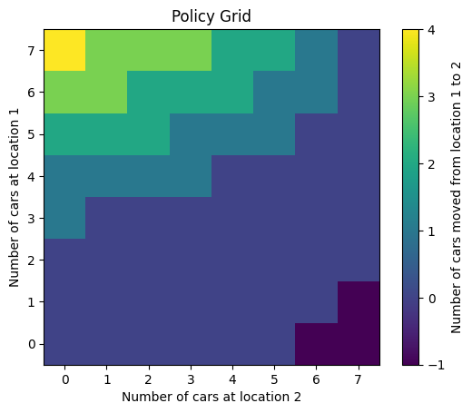

```
Policy Grid after iteration 2:
```

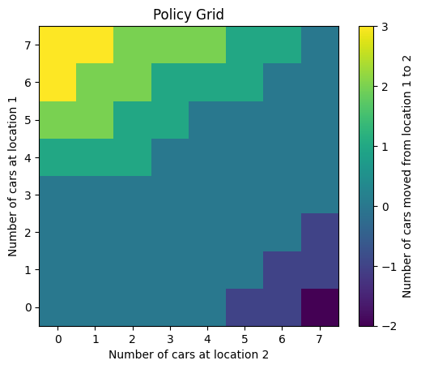

```
Policy Grid after iteration 3:
```

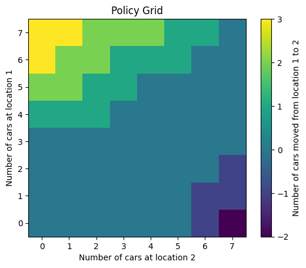

```
Policy Grid after iteration 4:
```

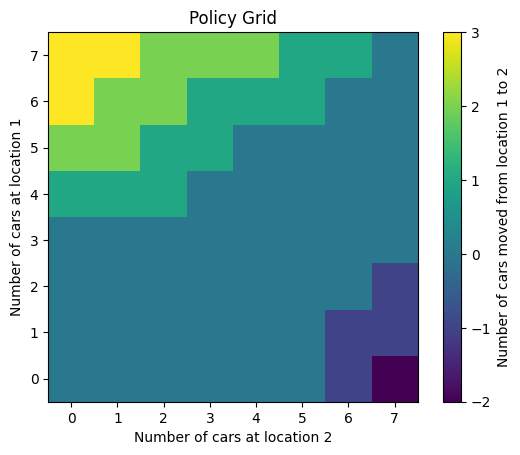

```
Optimal Policy:
[[ 0  0  0  0  0  0 -1 -2]
 [ 0  0  0  0  0  0 -1 -1]
 [ 0  0  0  0  0  0  0 -1]
 [ 0  0  0  0  0  0  0  0]
 [ 1  1  1  0  0  0  0  0]
 [ 2  2  1  1  0  0  0  0]
 [ 3  2  2  1  1  1  0  0]
 [ 3  3  2  2  2  1  1  0]]
Value Function:
[[205.66622403 214.87233351 223.87688706 232.44400023 240.34527064
  247.41878553 254.4807567  260.9256457 ]
 [214.7414912  223.94742411 232.95109387 241.51591991 249.41307664
  256.48076182 262.92565083 269.02589957]
 [223.24391499 232.4490733  241.44887733 250.00373216 257.88304662
  264.92565813 271.02590693 276.37050497]
 [230.78922581 239.99257438 248.98335591 257.51498294 265.35289531
  272.33773677 278.37051217 283.36755215]
 [237.99258173 246.98336208 255.51498891 263.85484919 271.62428861
  278.51404623 284.43670542 289.32332376]
 [244.98336858 253.51499442 261.85485424 269.62429385 276.6835367
  283.44876263 289.22790002 293.97176461]
 [251.51499915 259.85485885 267.6242982  274.68354143 281.44876748
  287.2279049  292.84217311 297.43108253]
 [257.85486283 265.62430188 272.68354658 279.44877308 285.22791064
  290.84218243 295.43109173 299.84909759]]
```

```python
def policy_iteration(policy = None, value_function = None):
    # 1. Initialization
    value_function = value_function or np.zeros(np.add(MAX_CARS,1))
    policy = policy or np.zeros((MAX_CARS[0] + 1, MAX_CARS[1] + 1), dtype=int)
    # For the arbitrary location version `np.zeros((*np.add(MAX_CARS,1),NUM_LOCATIONS))`
    policy_stable = False

    iteration = 0
    while not policy_stable:
        # 2. Policy Evaluation
        while True:
            delta = 0
            for index, action in np.ndenumerate(policy):
                old_value = value_function[index]
                new_value = expected_return((index), action, value_function)
                value_function[index] = new_value
                delta = max(delta, abs(old_value - new_value))
            if delta < THETA:
                break

        # 3. Policy Improvement
        policy_stable = True
        for index, old_action in np.ndenumerate(policy):
            action_returns = []
            for action in range(-MAX_MOVE, MAX_MOVE + 1):
                if (0 <= index[0] - action <= MAX_CARS[0]
                and 0 <= index[1] + action <= MAX_CARS[1]):
                    action_returns.append(
                        expected_return((index), action, value_function))
                else:
                    action_returns.append(-float('inf'))
            new_action = np.argmax(action_returns) - MAX_MOVE
            policy[index] = new_action
            if old_action != new_action:
                policy_stable = False

        print("Policy Grid after iteration {}: ".format(iteration + 1))
        plot_policy(policy)
        iteration += 1

    return policy, value_function


MAX_CARS = np.array([7,7])
# Run the policy iteration algorithm
policy, value_function = policy_iteration()
print("Optimal Policy:")
print(policy)
print("Value Function:")
print(value_function)
#1:52.7 @5x5
#8:33.7 @6x6
#28:33.7 @7x7
```

```
Policy Grid after iteration 1:
```

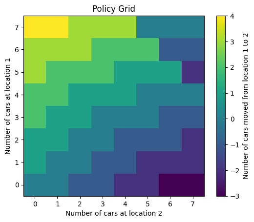

```
Policy Grid after iteration 2:
```

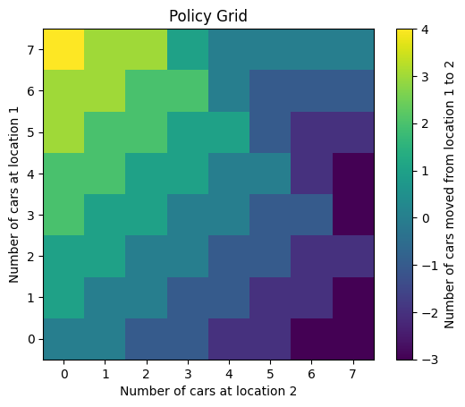

```
Policy Grid after iteration 3:
```

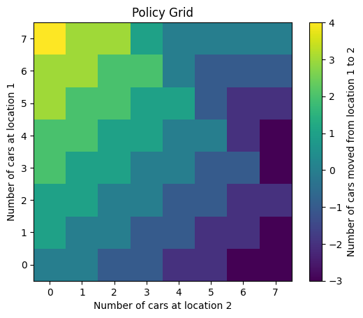

```
Optimal Policy:
[[ 0  0 -1 -1 -2 -2 -3 -3]
 [ 1  0  0 -1 -1 -2 -2 -3]
 [ 1  1  0  0 -1 -1 -2 -2]
 [ 2  1  1  0  0 -1 -1 -3]
 [ 2  2  1  1  0  0 -2 -3]
 [ 3  2  2  1  1 -1 -2 -2]
 [ 3  3  2  2  0 -1 -1 -1]
 [ 4  3  3  1  0  0  0  0]]
Value Function:
[[-114852.32613951 -115118.71847012 -115417.46163343 -116022.17551688
  -116734.51660144 -117774.84567433 -118999.47477723 -120568.54933754]
 [-115118.71846661 -115415.46162959 -116020.17551116 -116732.51659438
  -117772.84566619 -118997.47477027 -120566.54933048 -122326.77248779]
 [-115415.46161976 -116020.1755021  -116730.51658506 -117770.84565516
  -118995.47475966 -120564.5493195  -122324.77247931 -124203.92415988]
 [-116022.1754878  -116730.51657386 -117770.84564392 -118993.47474873
  -120562.54930785 -122322.77246893 -124201.92414946 -126161.21392704]
 [-116732.51656053 -117772.84563258 -118993.47473893 -120562.54929766
  -122320.77245889 -124199.92413926 -126159.21391986 -127968.07004459]
 [-117774.84562221 -118995.47472991 -120564.54928918 -122320.77245034
  -124199.92413048 -126157.21391144 -127966.07003787 -129976.93429186]
 [-118997.4747222  -120566.54928238 -122322.77244327 -124201.92412335
  -126155.21390316 -127964.0700299  -129974.9342838  -132199.66086447]
 [-120568.54927762 -122324.77243728 -124203.9241173  -126155.21388915
  -127962.07000675 -129972.93426031 -132197.66084134 -134492.26599426]]
```

```python
def policy_iteration(policy = None, value_function = None):
    # 1. Initialization
    value_function = value_function or np.zeros(np.add(MAX_CARS,1))
    policy = policy or np.zeros((MAX_CARS[0] + 1, MAX_CARS[1] + 1), dtype=int)
    # For the arbitrary location version `np.zeros((*np.add(MAX_CARS,1),NUM_LOCATIONS))`
    policy_stable = False

    iteration = 0
    while not policy_stable:
        # 2. Policy Evaluation
        while True:
            delta = 0
            for index, action in np.ndenumerate(policy):
                old_value = value_function[index]
                new_value = modified_return((index), action, value_function)
                value_function[index] = new_value
                delta = max(delta, abs(old_value - new_value))
            if delta < THETA:
                break

        # 3. Policy Improvement
        policy_stable = True
        for index, old_action in np.ndenumerate(policy):
            action_returns = []
            for action in range(-MAX_MOVE, MAX_MOVE + 1):
                if (0 <= index[0] - action <= MAX_CARS[0]
                and 0 <= index[1] + action <= MAX_CARS[1]):
                    action_returns.append(
                        modified_return((index), action, value_function))
                else:
                    action_returns.append(-float('inf'))
            new_action = np.argmax(action_returns) - MAX_MOVE
            policy[index] = new_action
            if old_action != new_action:
                policy_stable = False

        print("Policy Grid after iteration {}: ".format(iteration + 1))
        plot_policy(policy)
        iteration += 1

    return policy, value_function


MAX_CARS = np.array([7,7])
# Run the policy iteration algorithm
policy, value_function = policy_iteration()
print("Optimal Policy:")
print(policy)
print("Value Function:")
print(value_function)
#1:52.7 @5x5
#8:33.7 @6x6
```

## (c) Policy Insights

Although inefficiencies in the code above and limitations in the hardware employed to run the scripts prevented a full sized running of the solution, the general nature of the change in the policy can be distinctly seen. In particular, Jack is far more likely make the move that occurs free of charge. This resulted in the 'banding' being a bit wider than under the original problem conditions.

The extreme corner values increased to a higher number than in the base problem; but at this scale neither corner meets the maximum move limit. This could mean that the unconstrained optimal at those corners is higher, with the observable result being an increase in the areas of maximum movement (specifically the 5 and -4 on page 81).

Initially, the new lot fee was left to initiate at 10 cars. The effect of this change cannot be seen the smaller maximums. In order to attempt to recapture the probable effect of this factor we redefined this to be half of the location's max capacity.

Once the lot fee incurrence was reduced to actually effect the problem at this level the difference can be seen in the behavior on the upper right hand quadrant. In the original problem there is no consequence to being in this region, in fact having the inventory to service greater demand will be a potential benefit. Once the cost is added, there is a greater incentive to move vehicles to the other location to reduce the probability of having to rent an overflow lot. The new motive force can be visualized as:

[figure not shown]

## (d) Dynamic Programming

```
Value function update iteration 1, delta: 97.83327439972055
Value function update iteration 2, delta: 45.78239576760937
Value function update iteration 3, delta: 27.30041544076471
Value function update iteration 4, delta: 17.73890183656517
Value function update iteration 5, delta: 10.852840615654031
Value function update iteration 6, delta: 6.436770664102511
Value function update iteration 7, delta: 3.7785100323632435
Value function update iteration 8, delta: 2.2115610973956876
Value function update iteration 9, delta: 1.2933537500517787
Value function update iteration 10, delta: 0.7561818595401775
Value function update iteration 11, delta: 0.4421060002959081
Value function update iteration 12, delta: 0.2584723956609736
Value function update iteration 13, delta: 0.15111128824392495
Value function update iteration 14, delta: 0.0883442973178461
Value function update iteration 15, delta: 0.051648756575602306
Value function update iteration 16, delta: 0.030195424667979864
Value function update iteration 17, delta: 0.017653157129089436
Value function update iteration 18, delta: 0.010320568550824305
Value function update iteration 19, delta: 0.006033715880036539
Value function update iteration 20, delta: 0.003527492411194544
Value function update iteration 21, delta: 0.0020622785272479405
Value function update iteration 22, delta: 0.0012056702692007093
Value function update iteration 23, delta: 0.0007048712278105995
Value function update iteration 24, delta: 0.0004120889938548089
Value function update iteration 25, delta: 0.00024091966294292888
Value function update iteration 26, delta: 0.0001408489061276441
Value function update iteration 27, delta: 8.234452151612004e-05
Policy after value iteration:
```

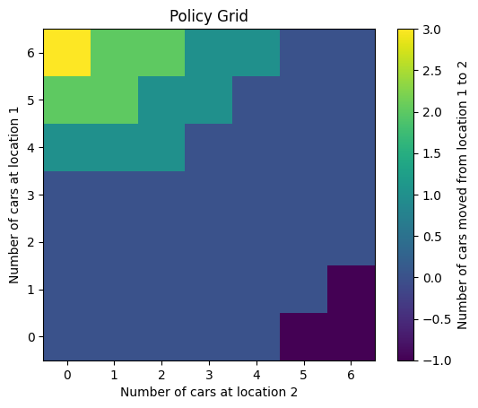

```
Optimal Policy:
[[ 0  0  0  0  0 -1 -1]
 [ 0  0  0  0  0  0 -1]
 [ 0  0  0  0  0  0  0]
 [ 0  0  0  0  0  0  0]
 [ 1  1  1  0  0  0  0]
 [ 2  2  1  1  0  0  0]
 [ 3  2  2  1  1  0  0]]
Value Function:
[[102.11426861 110.31823759 118.24676128 125.58114709 132.02101706
  138.0686674  143.41568985]
 [110.16980703 118.37358003 126.30113642 133.63307192 140.06867366
  145.41569623 150.73060627]
 [117.54191903 125.74485773 133.66831364 140.98990646 147.40759767
  152.73061497 156.879045  ]
 [123.78118433 131.98225826 139.8965644  147.19513965 153.57315173
  158.84337308 162.93404839]
 [129.98226676 137.89657143 145.19514636 152.0470583  158.36345931
  163.55212225 167.55428846]
 [135.89657861 143.1951524  150.04706377 156.36346493 161.8292083
  166.91951133 170.81546268]
 [141.19515744 148.04706914 154.36347063 159.82921726 164.91952067
  169.14213315 172.93353878]]
```

```python
def value_iteration(policy = None, value_function = None):
    # 1. Initialization
    value_function = value_function or np.zeros(np.add(MAX_CARS,1))
    policy = policy or np.zeros((MAX_CARS[0] + 1, MAX_CARS[1] + 1), dtype=int)

    iteration = 0
    while True:
        delta = 0
        for index, old_value in np.ndenumerate(value_function):
            action_returns = []
            for action in range(-MAX_MOVE, MAX_MOVE + 1):
                if (0 <= index[0] - action <= MAX_CARS[0]
                and 0 <= index[1] + action <= MAX_CARS[1]):
                    action_returns.append(
                        expected_return((index), action, value_function))
                else:
                    action_returns.append(-float('inf'))

            value_function[index] = max(action_returns)
            delta = max(delta, abs(old_value - value_function[index]))

        print(f"Value function update iteration {iteration+1}, delta: {delta}")
        if delta < THETA:
            break

        iteration += 1

    # Policy extraction from the value function
    for index, old_value in np.ndenumerate(value_function):
        action_returns = []
        for action in range(-MAX_MOVE, MAX_MOVE + 1):
            if (0 <= index[0] - action <= MAX_CARS[0]
            and 0 <= index[1] + action <= MAX_CARS[1]):
                action_returns.append(
                    expected_return((index), action, value_function))
            else:
                action_returns.append(-float('inf'))
        policy[index] = np.argmax(action_returns) - MAX_MOVE

    print("Policy after value iteration:")
    plot_policy(policy)
    return policy, value_function

MAX_CARS = np.array([6,6])
# Run value iteration algorithm
policy, value_function = value_iteration()
print("Optimal Policy:")
print(policy)
print("Value Function:")
print(value_function)
#3:2.6 @5x5
#14:26.5 @6x6
```

```
Value function update iteration 1, delta: 26407.693345747586
Value function update iteration 2, delta: 13252.561171691981
Value function update iteration 3, delta: 8025.179910451319
Value function update iteration 4, delta: 5423.878943659642
Value function update iteration 5, delta: 3408.378681659353
Value function update iteration 6, delta: 2046.9436141182741
Value function update iteration 7, delta: 1208.8607778772348
Value function update iteration 8, delta: 708.7260548774866
Value function update iteration 9, delta: 413.92018656563596
Value function update iteration 10, delta: 241.20307169784792
Value function update iteration 11, delta: 140.3924209712277
Value function update iteration 12, delta: 81.67993263000972
Value function update iteration 13, delta: 47.51543346667313
Value function update iteration 14, delta: 27.640276460224413
Value function update iteration 15, delta: 16.07857880503434
Value function update iteration 16, delta: 9.353030366481107
Value function update iteration 17, delta: 5.440725871856557
Value function update iteration 18, delta: 3.1649093932501273
Value function update iteration 19, delta: 1.8410504799176124
Value function update iteration 20, delta: 1.0709522438337444
Value function update iteration 21, delta: 0.622980583953904
Value function update iteration 22, delta: 0.36239226320321904
Value function update iteration 23, delta: 0.21080617234838428
Value function update iteration 24, delta: 0.12262745860789437
Value function update iteration 25, delta: 0.07133327019982971
Value function update iteration 26, delta: 0.04149507358670235
Value function update iteration 27, delta: 0.024137981192325242
Value function update iteration 28, delta: 0.014041236208868213
Value function update iteration 29, delta: 0.008167887695890386
Value function update iteration 30, delta: 0.004751318847411312
Value function update iteration 31, delta: 0.0027638759347610176
Value function update iteration 32, delta: 0.001607766593224369
Value function update iteration 33, delta: 0.0009352492052130401
Value function update iteration 34, delta: 0.0005440411623567343
Value function update iteration 35, delta: 0.0003164727604598738
Value function update iteration 36, delta: 0.00018409432232147083
Value function update iteration 37, delta: 0.00010708914487622678
Value function update iteration 38, delta: 6.229430437088013e-05
Policy after value iteration:
```

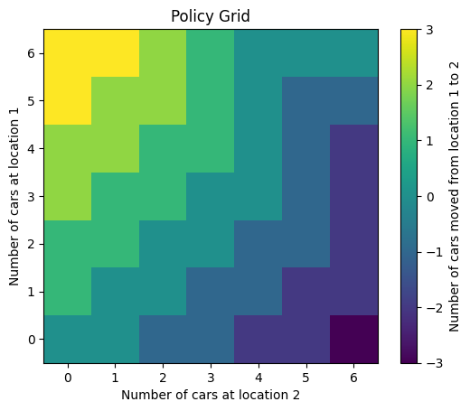

```
Optimal Policy:
[[ 0  0 -1 -1 -2 -2 -3]
 [ 1  0  0 -1 -1 -2 -2]
 [ 1  1  0  0 -1 -1 -2]
 [ 2  1  1  0  0 -1 -2]
 [ 2  2  1  1  0 -1 -2]
 [ 3  2  2  1  0 -1 -1]
 [ 3  3  2  1  0  0  0]]
Value Function:
[[-38917.89299437 -39118.39576682 -39338.32829574 -39787.76881278
  -40296.3627526  -41054.79346137 -41902.7650907 ]
 [-39118.39576885 -39336.32829796 -39785.76881607 -40294.36275663
  -41052.79346599 -41900.76509461 -43019.5219744 ]
 [-39336.32830354 -39785.76882117 -40292.36276181 -41050.79347206
  -41898.76510039 -43017.52198034 -44203.38973193]
 [-39787.768829   -40292.36276788 -41050.79347808 -41896.76510616
  -43015.52198643 -44201.38973731 -45440.42054634]
 [-40294.36277487 -41052.793484   -41896.7651112  -43015.52199163
  -44199.38974236 -45438.42055095 -46645.5245701 ]
 [-41054.79348924 -41898.76511575 -43017.5219959  -44199.38974661
  -45436.42055531 -46643.52457422 -47985.72168021]
 [-41900.76511955 -43019.52199937 -44201.38975092 -45436.42056208
  -46641.52458528 -47983.72169127 -49416.63167809]]
```

```python
def value_iteration(policy = None, value_function = None):
    # 1. Initialization
    value_function = value_function or np.zeros(np.add(MAX_CARS,1))
    policy = policy or np.zeros((MAX_CARS[0] + 1, MAX_CARS[1] + 1), dtype=int)

    iteration = 0
    while True:
        delta = 0
        for index, old_value in np.ndenumerate(value_function):
            action_returns = []
            for action in range(-MAX_MOVE, MAX_MOVE + 1):
                if (0 <= index[0] - action <= MAX_CARS[0]
                and 0 <= index[1] + action <= MAX_CARS[1]):
                    action_returns.append(
                        modified_return((index), action, value_function))
                else:
                    action_returns.append(-float('inf'))

            value_function[index] = max(action_returns)
            delta = max(delta, abs(old_value - value_function[index]))

        print(f"Value function update iteration {iteration + 1}, delta: {delta}")
        if delta < THETA:
            break

        iteration += 1

    # Policy extraction from the value function
    for index, old_value in np.ndenumerate(value_function):
        action_returns = []
        for action in range(-MAX_MOVE, MAX_MOVE + 1):
            if (0 <= index[0] - action <= MAX_CARS[0]
            and 0 <= index[1] + action <= MAX_CARS[1]):
                action_returns.append(
                    modified_return((index), action, value_function))
            else:
                action_returns.append(-float('inf'))
        policy[index] = np.argmax(action_returns) - MAX_MOVE

    print("Policy after value iteration:")
    plot_policy(policy)
    return policy, value_function

MAX_CARS = np.array([6,6])
# Run value iteration algorithm
policy, value_function = value_iteration()
print("Optimal Policy:")
print(policy)
print("Value Function:")
print(value_function)
#3:2.6 @5x5
#14:26.5 @6x6
```

## (e) Algorithm Comparison

It is possible that that all observations are the result of bias in the coding of each algorithm.

Value iteration seemed to be a more straightforward implementation than policy iteration. However, when the two were implemented with the intent to keep their operation as similar as possible the policy iteration concluded in significantly shorter time. The resulting policies were quite similar, but under the extended problem the behavior in the quadrant marking overflow lot usage appears to blend more with the behavior outside the quadrant at the edges.